# MCS Coding to Solve Physics Problems 1

## Introduction to simulations

### Constant Velocity

Assume you have a cart on a frictionless track. At time t = 0 seconds, the cart is at a position x = 0 m. The cart is moving with a constant velocity of 0.45 m/s (in the x-direction).

- Where is the cart at time t = 1.5 seconds?
- What about at 0.25 seconds?
- Assume the cart continues to travel for another 0.25 seconds (a total of 0.5 seconds) where is it now?
- How many steps of 0.25 seconds would you need to calculate in order to determine the position at 1.5 seconds?
- What if you used a time step size of 0.1 seconds?

In that final case you could imagine filling in a table that looked like:

| time (s) | x position (m) |
| --- | --- |
| 0 | 0 |
| 0.1 | 0.045 |
| 0.2 | ... |

If you know the position (x value) for an object at a particular time and you also know the average velocity, you can find the position at the next time. Suppose I have the third position and I want want to find the 4th position. This would be the formula: $$x_4 = x_3 + v \Delta t$$ where $\Delta t$ is the time step size.

Clearly, you could do the calculations above for any number of steps. It might get crazy for a long time or a small time step, but you could theoretically do it. Using our python skills we can do this.

```
import matplotlib.pyplot as plt
x = 0 #this is the inital position
t = 0 #this is the inital time
v = 0.45 #this is the velocity
dt = 0.1 #this is the time-step

X=[x] #these will be the arrays of all x and time
T=[t]

while t<1.5:
    x=x+v*dt #this calculates the next position
    t=t+dt #this calculates the next time
    X.append(x) #this 'appends' the latest value of x and t to the arrays X and T
    T.append(t)


print('at time t=',t,'our x value is',x)
#notice the print statement is not indented so is not part of the while loop.
```

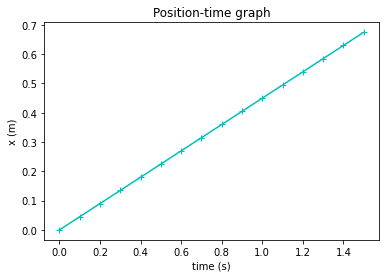

```python
plt.plot(T,X,'c-+') #this plots the array T on the x-axis and array X on the y-axis.
plt.title('Position-time graph') #you can work out the next 3 lines
plt.xlabel('time (s)')
plt.ylabel('x (m)')
plt.show()
```

Edit the program to answer the following:

- Where will the cart be when t=2.2 seconds?
- If the cart has a velocity of 0.62m/s, where will it be at t=2.2 seconds.
- If the cart has a starting potsition of -0.5m and a velocity of 0.62m/s, where will it be at t=2.2 seconds?

### Constant acceleration

A cart starts at x = 0 meters with a velocity of 0.45 m/s at a time of t = 0 seconds. If the cart has an acceleration of 0.2 m/s<sup>2</sup>, where will the cart be after 1.5 seconds?

So in each time step you can calculate the new velocity based on the acceleration, the old velocity and the time step. What about the change in position? You can still use the position update formula from above – but we need to make a choice. Since we might not know the average velocity, we will just use the final velocity instead. Here is the order of calculations for each time step:

- Use the velocity update formula to find the new velocity
- Use the position update formula (with the new velocity) to find the new position
- Update time.

Again we can make a table of these updates

| time (s) | v (m/s) | x position (m) |
| --- | --- | --- |
| 0 | 0.45 | 0 |
| 0.25 | ... | ... |
| 0.5 | ... | ... |

```
import matplotlib.pyplot as plt
x = 0 #this is the inital position
t = 0 #this is the inital time
v = 0.45 #this is the inital velocity
a=0.2 #this is the acceleration

dt = 0.1 #this is the time-step

X=[x] #these will be the arrays of all x, time and velocity
T=[t]
V=[v]

while t<1.5:
    v=v+a*dt #this calculates the next velocity
    x=x+v*dt #this calculates the next position
    t=t+dt #this calculates the next time
    X.append(x) #this 'appends' the latest value of x and t to the arrays X, T and V
    T.append(t)
    V.append(v)


print('at time t=',t,'our x value is',x)
#notice the print statement is not indented so is not part of the while loop.
```

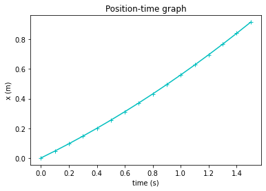

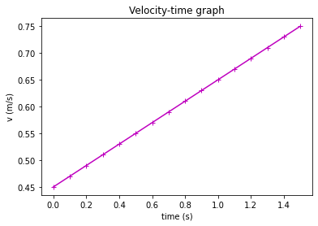

```python
plt.plot(T,X,'c-+') #this plots the array T on the x-axis and array X on the y-axis.
plt.title('Position-time graph') #you can work out the next 3 lines
plt.xlabel('time (s)')
plt.ylabel('x (m)')
plt.show()

plt.plot(T,V,'m-+')
plt.title('Velocity-time graph')
plt.xlabel('time (s)')
plt.ylabel('v (m/s)')
plt.show()
```

#### Change the code to answer the following:

- What happens if you put the time step (not the time) to 0.2 seconds?
- What happens if you put the time step to 0.01 seconds?
- What if the acceleration is -0.01 m/s2?
- When using the kinematic equation to find the location after 1.5 seconds, we got a value of 0.9 meters. Why do we get a different value here? How could you get the program to give you a value closer to 0.9 meters?
- If the acceleration is -0.02 m/s2, how long (in time) would it take to stop? Where would it stop? (hint: try printing the velocity at the end) (double hint: you can try changing the time in the loop – line 7)

## 2 cars 2 questions

Car A starts at x = 0.5 m with a velocity of 0.45 m/s. Car B starts at x = 0 with a velocity of 0 m/s but has an acceleration of 0.2 m/s2. When does Car B catch up to Car A? Where do they meet? Fill in the blanks in the programme or write from scratch.

```
xA=0.5 #m
xB=0
vA=0.45
vB=0
aB=0.2 #m/s^2
t=0
dt=0.01 #s

XA=[xA]
XB=[xB]
T=[t]
while xxxxx:
    xxxxxxxxxx
    xxxxxxxxxx
    xxxxxxxxxx
    xxxxxxxxxx

    XA.append(xA)
    XB.append(xB)
    T.append(t)
```

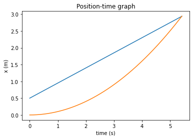

```python
plt.plot(T,XA)
plt.plot(T,XB)
plt.title('Position-time graph')
plt.xlabel('time (s)')
plt.ylabel('x (m)')
plt.show()
```

You are a police officer in a stationary car. Another car drives past you traveling at a constant speed of 40 m/s. It takes you 3 seconds to pull out and then you accelerate to catch the speeder. Your car has a constant acceleration of 6 m/s^2 with a maximum speed of 60 m/s. How long before you catch the car and how far are you from your starting position? Again you can use the framework below.

```
xp=0
xs=0
t=0
dt=0.1

Xp=[xp]
Xs=[xs]
T=[t]

vs=40


#this is the max speed of police
vpmax=60
vp=0

#acceleration of police.
#ap is the starting value
ap=0
#apa is the value when acceleratinge
apa=6



#this is the time to wait for the start of police
twait=3

while xxxxx:
    xxx
    if xxxx and xxxx:
        xxxx

    #update velocity of police car
    xxxxxxxx
    #update position of cars
    xxxxxxxx
    t=t+dt
    Xs.append(xs)
    Xp.append(xp)
    T.append(t)
```

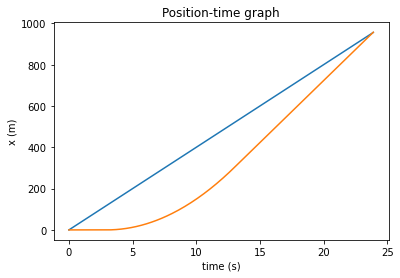

```python
plt.title('Position-time graph')
plt.xlabel('time (s)')
plt.ylabel('x (m)')
plt.plot(T,Xs)
plt.plot(T,Xp)
plt.show()
```

## Exercise: Projectile Motion

Now we have mastered motion in one dimesion we can progress to two. Suppose I launch an object with an initial velocity $v_0$ with an angle θ above the horizontal. The projectile experiences constant acceleration downward but none in the horizontal direction. To do this we will need to decompose the velocity into $v_x = v \cos(\theta)$ and $v_y = v\sin(\theta)$. To access these functions we can import them from numpy with the line: `from numpy import sin,cos,pi`.

- Write a programme to find the x distance travelled for a projectile of 10kg fired at 15m/s at 45 degrees to the horizontal from a vantage point 2m above the ground.
  - Set initial conditions (starting x and y, starting velocities - both x and y)
  - Make a loop
  - In the loop, calculate the force and acceleration. You don't technically have to do this since it doesn't change - but I recommend doing it to practice for cases where the force DOES matter.
  - Update the velocity in the y direction (you don't have to do this for the x-direction since it's constant).
  - Update the position of the ball (both x and y)
  - Update time.
  - Repeat.
- We know (and can prove) that firing our projectile at 45 degrees gives us the largest x-range. Is this true when $y_0 \neq 0$? What is it in the above case?

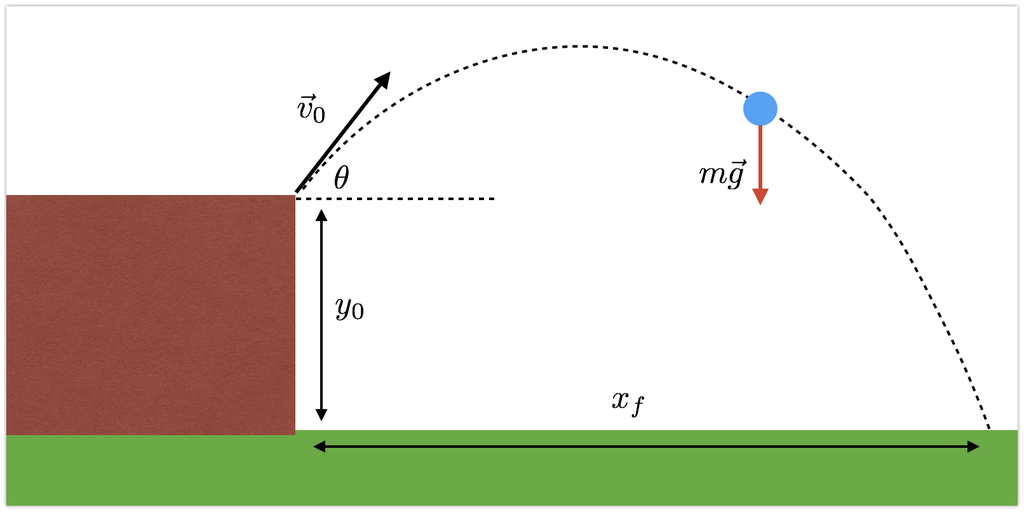

## Exercise: Falling + Air Resistance

We now know enough python to solve problems that would be very hard to solve otherwise. Imagine a cannon ball falling straight down from a great height. The resultant force in the downward direction is: $F=mg - Cv^2$ where $C$ is a constant dependent on the aerodynamic properties of the ball, the ball's surface area and the density of air. Now the force is dependent on the balls velocity.

- A 20kg cannonball is dropped from 100m. It has a terminal velocity of 100m/s. Write a programme to calculate the time taken for the ball to hit the ground. (You'll have to calculate $C$ first.)
- The same cannonball is now fired at 700m/s at 45 degrees to the horizontal. Calculate the difference in distance travelled when you include air resistance.
  - You'll need to take into account that the direction of air resistance will change. It might help to write air resistance as $\vec{F}=-C|v|\vec{v}$

## Excercise: Mass on a spring

- A ball with a mass of 0.1 kg is connected to a spring.
- The spring has a spring constant $k$ of 10 Newtons per meter.
- The force on the ball is $F = -kx$ where $x$ is the distance from the origin.
- The ball starts at rest and at a position of x = 0.1 meters.

#### Write a simulation for a this situation and plot position of the ball vs time

- The exact solution should be $x=x_0 \cos(\omega t)$ where $\omega = \sqrt{k/m}$. Describe any differences. What causes them? Are they physical?

#### Total Energy

The total energy in this system is the total of kinetic energy and potential. In this system this is equal to $\frac{1}{2}mv^2+\frac{1}{2}kx^2$. Investigate the impact of updating position before velocity in the simulation. Look at a single time step and see if energy remains constant in both cases.

#### Repeat for a spring hanging vertically so that the mass feels force from gavity as well. Try this for a number of inital positions

#### Instead of gravity, now consider a damping term such that the force on the ball is $\vec{F}=-k\vec{x} - C\vec{v}.$ Experiment what happens for different values of $C$.

#### Finally we can add a driving force $F=A\sin(\omega_0t)$ to the system. Investigate what happens at different frequencies of $\omega_0$.